# Fluoroquinolones

## Fluoroquinolones

**Russell E. Lewis**  
Associate Professor of Infectious Diseases (MEDS-10/B)

russelledward.lewis@unipd.it  
[https://github.com/Russlewisbo](https://github.com/Russlewisbo/ESCMID_2022_talk)  
Slides and course materials: [www.idpadova.com](https://padovaid.com/)

## Learning objectives:

1. Describe the mechanism of action of fluoroquinolones
2. Explain resistance mechanisms and their clinical implications
3. Compare the spectrum of activity among different quinolones
4. Apply pharmacokinetic principles to dosing decisions
5. Select appropriate quinolone therapy for common infections
6. Recognize important adverse effects and drug interactions

## Quinolone evolution

| Generation | Examples | Key Features |
| --- | --- | --- |
| 1st | Nalidixic acid | UTI only; narrow spectrum |
| 2nd | Norfloxacin, Ciprofloxacin | Broader gram-negative; systemic use |
| 3rd | Levofloxacin | Enhanced gram-positive |
| 4th | Moxifloxacin, Gemifloxacin | Enhanced respiratory pathogens |

The quinolones have evolved dramatically. First-generation agents like nalidixic acid were limited to UTIs. Modern fluoroquinolones have much broader activity and systemic applications. (Domagala, 1994; Wolfson and Hooper, 1989)

## Currently available quinolones

**Older agents:**

- Norfloxacin
- Ciprofloxacin
- Ofloxacin

**Newer agents:**

- Levofloxacin
- Moxifloxacin
- Gemifloxacin (not available in Italy)
- Delafloxacin

These are the quinolones currently available in clinical practice. Ciprofloxacin and levofloxacin are the most commonly used. Delafloxacin is the newest addition, approved for skin infections.

## Quinolone structures

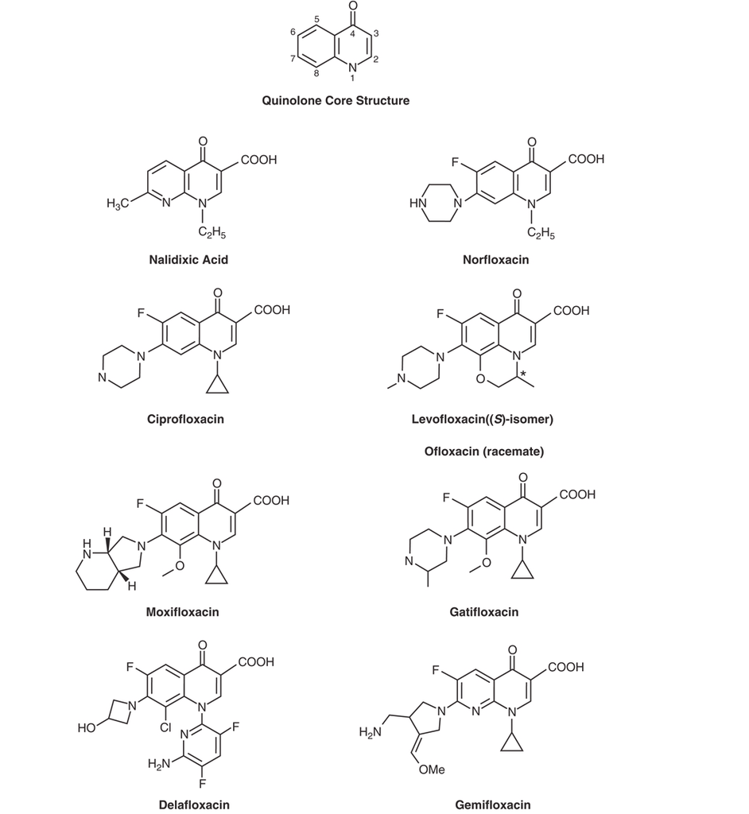

All quinolones share a bicyclic core with a carboxylic acid at C-3 and a ketone at C-4 — essential for binding to the topoisomerase-DNA complex. The fluorine at C-6 (the “fluoro” in fluoroquinolone) dramatically improves gram-negative potency and bioavailability compared to nalidixic acid. The C-7 substituent (piperazinyl, pyrrolidinyl, etc.) is the primary determinant of spectrum: bulkier cyclic amines at C-7 expand gram-positive and anaerobic activity. Substitutions at N-1 and C-8 further tune pharmacokinetics and target selectivity (Domagala, 1994).

# Mechanism of Action

## Primary targets: Topoisomerases

Quinolones target two essential bacterial enzymes:

- **DNA Gyrase** (GyrA, GyrB subunits)
- **Topoisomerase IV** (ParC, ParE subunits)
- Both are Type II topoisomerases required for DNA replication.

The key to understanding quinolone action is recognizing these two targets. Both are essential for bacterial survival, and quinolones exploit this by trapping them in complexes with DNA. (Drlica and Hooper, 2003; Wang, 1996)

## DNA gyrase function

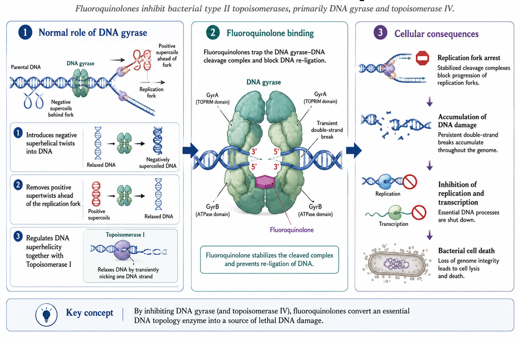

DNA gyrase is the only enzyme that can introduce negative supercoils. This is essential for compacting the bacterial chromosome and for DNA replication to proceed. (Drlica and Zhao, 1997; Wang, 1996)

## Topoisomerase IV function

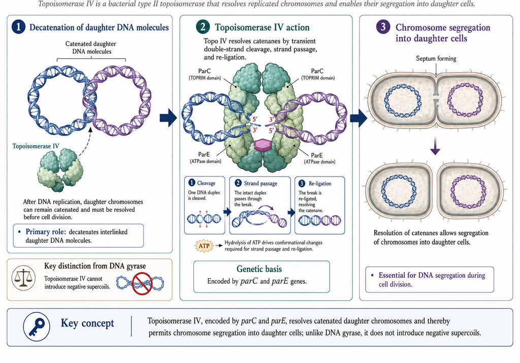

When circular DNA replicates, the two daughter molecules are interlocked like chain links. Topoisomerase IV separates them so they can partition into daughter cells. (Kato et al., 1990)

## Species-dependent primary targets

| Organism Type | Primary Target | Secondary Target |
| --- | --- | --- |
| Gram-negative | DNA Gyrase | Topoisomerase IV |
| Gram-positive | Topoisomerase IV | DNA Gyrase |

This is clinically important because it affects resistance development. The organism’s more sensitive enzyme determines the primary target for a given quinolone. (Drlica and Hooper, 2003; Hooper and Jacoby, 2016)

## Mechanism of bacterial killing

**How quinolones kill bacteria:**

1. Bind to topoisomerase-DNA complex (not enzyme alone)
2. Block resealing of DNA double-strand breaks
3. Stabilize covalent enzyme-DNA intermediates
4. Create barriers to replication fork and transcription
5. Convert to permanent DNA breaks → cell death

Quinolones don’t simply inhibit enzyme function—they convert these enzymes into DNA-damaging agents. This “poisoning” of the topoisomerases is what makes quinolones bactericidal. (Drlica and Hooper, 2003; Kohanski et al., 2007)

## Bactericidal activity features

**Key Point**

- Bactericidal activity increases with drug concentration
- Maximum killing at ~30× MIC
- Paradoxical decrease at very high concentrations

**Post-antibiotic effect:** 1-2 hours

The concentration-dependent killing and post-antibiotic effect support once-daily or extended-interval dosing strategies that maximize peak concentrations. (Drlica and Hooper, 2003)

# Resistance Mechanisms

## Overview of resistance

Quinolone resistance occurs through:

1. **Target mutations** — alterations in GyrA, GyrB, ParC, ParE
2. **Efflux pumps** — active drug extrusion
3. **Plasmid-mediated** — qnr genes, modifying enzymes

Resistance is multifactorial and often involves combinations of these mechanisms. Understanding them helps predict cross-resistance patterns and guide empirical therapy. (Hooper and Jacoby, 2016; Jacoby, 2005)

## Target mutations: QRDR

**Quinolone Resistance-Determining Region (QRDR):**

- GyrA mutations cluster at amino acids 67-106
- Most common: Serine-83 → Leucine/Tryptophan
- Similar “hot spots” in ParC (position 80)

The QRDR is near the active site of the enzyme. Mutations here reduce quinolone binding while preserving enzyme function. Serine-83 mutations in GyrA cause the largest resistance increments. (Hooper and Jacoby, 2016; Jacoby, 2005)

## Stepwise resistance development

1. First mutation in primary target enzyme
2. Low-level resistance (8-fold MIC increase)
3. Second mutation in secondary target
4. High-level clinical resistance

**Warning**

Serial passage selects progressively resistant mutants!

This is why monotherapy for serious infections can be problematic. Sequential mutations accumulate, and having two targets provides only partial protection if both can mutate. (Drlica and Hooper, 2003; Hooper and Jacoby, 2016)

## Efflux pumps: Gram-negatives

| Organism | Pump System | Clinical Significance |
| --- | --- | --- |
| *E. coli* | AcrAB-TolC | Often combined with gyrA mutations |
| *P. aeruginosa* | MexAB-OprM | Common in clinical isolates |
| *P. aeruginosa* | MexCD-OprJ | Selected by fluoroquinolone use |
| *K. pneumoniae* | OqxAB-TolC | Plasmid-encoded |

These pumps belong to the RND family and have broad substrate profiles—hence the term “multidrug resistance pumps.” Overexpression contributes to resistance to multiple antibiotic classes. (Piddock, 2006; Poole, 2000)

## Efflux pumps: Gram-positives

**S. aureus:**

- NorA — hydrophilic quinolones (norfloxacin > ciprofloxacin > levofloxacin)
- NorB, NorC — broader substrate range
- MepA — MATE family pump

**Tip**

Moxifloxacin is not affected by NorA overexpression!

Efflux pumps in gram-positives show variable substrate profiles. This explains why some quinolones retain activity when others don’t, even against the same organism. (Piddock, 2006)

## Plasmid-mediated resistance: Qnr

**Qnr proteins** protect topoisomerases from quinolone action:

- Seven families: qnrA, qnrB, qnrS, qnrC, qnrD, qnrE, qnrVC
- Found in 1-7% of Enterobacterales
- Alone cause only low-level resistance
- **BUT:** Facilitate selection of chromosomal mutations

Qnr genes are particularly concerning because they lower the threshold for selecting resistant mutants. They’re often found on plasmids carrying other resistance genes, contributing to MDR. (Martínez-Martínez et al., 1998; Strahilevitz et al., 2009; Tran and Jacoby, 2002)

## Plasmid-mediated: Modifying enzymes

**AAC(6’)-Ib-cr:**

- Variant aminoglycoside acetyltransferase
- Acetylates piperazinyl nitrogen of ciprofloxacin/norfloxacin
- Causes 3-4 fold MIC increase
- Does NOT affect moxifloxacin, levofloxacin

This enzyme specifically targets quinolones with an unsubstituted piperazinyl nitrogen. It’s another example of how resistance mechanisms can show quinolone-specific effects. (Robicsek et al., 2006)

## Clinical implications of resistance

**Rising Resistance**

- *E. coli*: 20-40% resistance in some areas…in Italy can approach 70-90%
- *P. aeruginosa*: 20-30% resistance
- *N. gonorrhoeae*: No longer recommended empirically
- *Salmonella*: Increasing worldwide

These resistance rates have major clinical implications. We can no longer rely on fluoroquinolones for empirical treatment of gonorrhea, and their use for other infections requires local susceptibility data. (Hooper and Jacoby, 2016)

# Antimicrobial Activity

## Spectrum overview

**Best Activity:**

- Enterobacterales
- *Haemophilus* spp.
- *Neisseria* spp.
- *Moraxella catarrhalis*

**Variable Activity:**

- *P. aeruginosa* (cipro, levo)
- Streptococci (newer agents)
- Anaerobes (moxi, dela)

## Gram-negative activity

**Ciprofloxacin**

Remains the most potent quinolone against gram-negative bacteria, especially *P. aeruginosa*

- Only ciprofloxacin and levofloxacin suitable for *Pseudomonas*
- Resistance may emerge during monotherapy for serious infections

For serious pseudomonal infections, combination therapy is often recommended to prevent resistance emergence. Ciprofloxacin’s gram-negative potency makes it the preferred quinolone for these infections. (Eliopoulos and Eliopoulos, 2003)

## Gram-positive activity comparison

MIC<sub>90</sub> values (μg/mL)

| Organism | Cipro | Levo | Moxi | Gemi | Dela |
| --- | --- | --- | --- | --- | --- |
| MSSA | 0.5 | 0.25 | 0.12 | 0.06 | 0.008 |
| MRSA | ≥32 | 16 | 4 | 8 | 0.5 |
| *S. pneumoniae* | 2 | 1 | 0.25 | 0.06 | 0.015 |

## Respiratory pathogens

“Respiratory fluoroquinolones” have enhanced activity against:

- *Streptococcus pneumoniae*
- *Legionella pneumophila*
- *Mycoplasma pneumoniae*
- *Chlamydia pneumoniae*

**Agents:** levofloxacin, moxifloxacin, gemifloxacin

This enhanced respiratory pathogen coverage makes these agents attractive for CAP monotherapy, covering both typical and atypical pathogens with a single agent. (Mandell et al., 2007; Metlay et al., 2019)

## Anaerobic activity

| Agent | B. fragilis MIC<sub>90</sub> |
| --- | --- |
| Ciprofloxacin | 4-64 |
| Levofloxacin | 2->16 |
| **Moxifloxacin** | **0.5-8** |
| **Delafloxacin** | **0.12** |

**Note**

Most quinolones have poor anaerobic activity; moxifloxacin and delafloxacin are exceptions.

This is important for intra-abdominal infections and diabetic foot infections where anaerobic coverage is needed. Ciprofloxacin requires additional anaerobic coverage for these indications. (Eliopoulos and Eliopoulos, 2003)

## Mycobacterial activity

| Agent | M. tuberculosis | M. avium | M. fortuitum |
| --- | --- | --- | --- |
| Ciprofloxacin | 1 | 16 | 0.3->4 |
| Levofloxacin | 0.25-1 | 0.5-64 | 0.06-2 |
| Moxifloxacin | 0.125-0.5 | 0.5-16 | 0.06-1 |

Moxifloxacin is the most potent agent against M. tuberculosis and is now included in MDR-TB regimens. Activity against MAC is poor across all agents. (Gillespie et al., 2014)

## Anthrax and bioterrorism

**CDC Recommendations**

- Ciprofloxacin and levofloxacin recommended for anthrax prophylaxis
- Similar efficacy to doxycycline
- Quinolone resistance can be selected in *B. anthracis*

# Pharmacology

## Absorption characteristics

- Bioavailability: 50-100% (most >70%)
- Peak levels: 1-3 hours post-dose
- Food delays but doesn’t significantly reduce absorption
- Enteral feeding may reduce absorption

The excellent oral bioavailability of most quinolones allows oral step-down therapy and outpatient treatment of serious infections. This is a major advantage over many other antibiotic classes. (Dudley, 2003)

## Peak serum concentrations

| Quinolone | Dose (mg) | C<sub>max</sub> (μg/mL) |
| --- | --- | --- |
| Norfloxacin | 400 PO | 1.5 |
| Ciprofloxacin | 500 PO | 2.4 |
| Ofloxacin | 400 PO | 4.6 |
| Levofloxacin | 500 PO | 5.7 |
| Moxifloxacin | 400 PO | 4.3 |
| Delafloxacin | 450 PO | 7.45 |

Delafloxacin achieves the highest peak levels. For concentration-dependent killing, these peak levels matter for efficacy and reducing resistance selection. (Dudley, 2003)

## Tissue distribution

Concentrations **exceeding** serum levels:

| Site | Fold Increase |
| --- | --- |
| Feces | 100-1000× |
| Macrophages/Neutrophils | 2->100× |
| Bile | 2-20× |
| Lung tissue | 1.6-6× |
| Prostate tissue | 0.9-2.3× |

High intracellular concentrations make quinolones effective against intracellular pathogens like Legionella, Chlamydia, and mycobacteria. Prostate penetration supports use in prostatitis. (Dudley, 2003)

## CSF penetration

**Warning**

CSF penetration is generally **LOW** without meningeal inflammation

- Better than β-lactams in uninflamed meninges
- Levofloxacin ≈ Moxifloxacin > Ciprofloxacin
- Active efflux may limit CNS concentrations

While quinolones are not first-line for meningitis, they may have a role in specific situations like tuberculous meningitis or when other options are limited. (Heemskerk et al., 2016; Nau et al., 2010)

## Elimination routes

**Primarily Renal:**

- Ofloxacin
- Ciprofloxacin
- Levofloxacin

Requires dose adjustment in renal impairment

**Primarily Hepatic:**

- Moxifloxacin
- Nalidixic acid

No renal dose adjustment

Knowing the elimination route is essential for dosing. Moxifloxacin is particularly useful when you don’t want to adjust for renal function or when high urinary concentrations aren’t needed. (Dudley, 2003)

## Renal dosing adjustments

| Agent | CrCl 10-50 | CrCl <10 |
| --- | --- | --- |
| Norfloxacin | q24h | q24h |
| Ciprofloxacin | q18h | q24h |
| Ofloxacin | q24h | ½ dose q24h |
| Levofloxacin | ½ dose q24h | ½ dose q48h |
| **Moxifloxacin** | **No change** | **No change** |

Moxifloxacin’s lack of need for renal adjustment makes it attractive in patients with fluctuating renal function or when levels won’t be monitored closely. (Dudley, 2003)

## Drug interactions: Cations

**Critical interaction**

Aluminum, magnesium, calcium, iron, and zinc form poorly absorbed chelates with quinolones.

**Timing:** Take quinolone 2 hours before or 2-6 hours after these agents

This is one of the most important drug interactions to remember. Antacids, supplements, sucralfate, and even tube feeds can dramatically reduce quinolone absorption. (Radandt et al., 1992)

## Drug interaction: CYP1A2

**Ciprofloxacin inhibits CYP1A2:**

| Drug | Effect |
| --- | --- |
| Theophylline | 30% ↓ clearance; monitor levels |
| Caffeine | ↑ levels |
| Tizanidine | ↑ CNS/hypotensive effects; AVOID |
| Clozapine | ↑ levels; monitor |

**Note**

Other quinolones have minimal CYP1A2 effects

Ciprofloxacin is the main culprit here. The tizanidine interaction is particularly important—concomitant use can cause severe hypotension and sedation. (Radandt et al., 1992)

## Drug interactions: QT prolongation

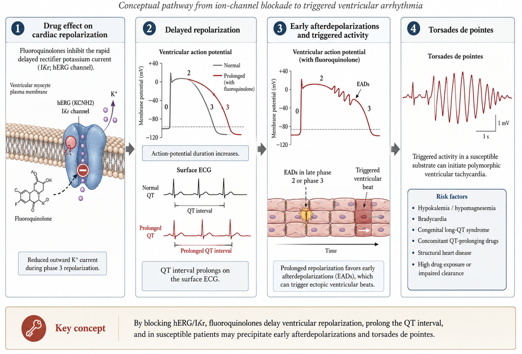

## Drug interactions: QT prolongation

**Warning**

Avoid combining with other QT-prolonging agents:

- Antiarrhythmics (Class IA, III)
- Antipsychotics
- TCAs
- Macrolides
- Azole antifungals

**Risk:** Moxifloxacin > Levofloxacin > Ciprofloxacin

QT prolongation is a class effect but varies by agent. In high-risk patients, consider ciprofloxacin if a quinolone is necessary. (Yap and Camm, 2003)

# Clinical Applications

## Urinary tract infections

**Uncomplicated cystitis (3-day course):**

- 81-96% cure rates
- Comparable to TMP-SMX, nitrofurantoin
- **BUT:** Not recommended first-line due to collateral damage

**Warning**

Reserve for patients with contraindications to first-line agents

While highly effective, quinolones are no longer first-line for uncomplicated UTI due to concerns about resistance selection, adverse effects, and availability of safer alternatives. (Gupta et al., 2011; Hooton et al., 2013)

## Complicated UTIs and pyelonephritis

- 7-14 day treatment duration
- Ciprofloxacin, levofloxacin: 95% eradication rates
- Good coverage of resistant gram-negatives
- Oral bioequivalent to IV for most patients

For complicated UTIs, quinolones remain important options because they cover the resistant gram-negatives often involved and can be given orally for outpatient therapy. (Gupta et al., 2011)

## Prostatitis

**First-line for chronic bacterial prostatitis**

- Excellent prostatic penetration
- Treatment duration: 4-6 weeks
- Ciprofloxacin or levofloxacin preferred

The prostatic penetration and gram-negative coverage make quinolones ideal for prostatitis.  
The long duration ensures eradication from the difficult-to-penetrate prostatic tissue. (Naber et al., 2008)

## Sexually transmitted infections

**NO longer recommended for empirical gonorrhea treatment!**

- High resistance rates (>30% in many areas)
- Use only if susceptibility confirmed
- Still effective for *Chlamydia* and *M. genitalium*

This is a major change from previous practice. Ceftriaxone is now standard for gonorrhea.  
However, quinolones remain useful for other STIs like chlamydia when alternatives are contraindicated. (Hooper and Wolfson, 1989)

## Gastrointestinal infections

| Indication | Agent | Duration |
| --- | --- | --- |
| Shigellosis | Ciprofloxacin | 3 days |
| Traveler’s diarrhea | Ciprofloxacin | 1-3 days |
| Typhoid (susceptible) | Ciprofloxacin | 5-7 days |
| Severe *Salmonella* | Ciprofloxacin | 7-14 days |

**Warning**

Watch for resistance in *Salmonella* from South/Southeast Asia

Quinolones remain first-line for shigellosis and traveler’s diarrhea.  
For typhoid, azithromycin or ceftriaxone may be preferred in areas with high quinolone resistance.

## Community-acquired pneumonia

“Respiratory fluoroquinolones” provide:

- Coverage of *S. pneumoniae* (including drug-resistant)
- Activity against atypical pathogens
- Single-agent monotherapy option
- Oral or IV options

For patients with comorbidities, recent antibiotics, or in areas with high pneumococcal macrolide resistance, respiratory fluoroquinolones offer convenient monotherapy. (Mandell et al., 2007; Metlay et al., 2019)

## CAP: When to use quinolones

**IDSA/ATS Guidelines**

Consider respiratory fluoroquinolones for CAP in:

- Patients with comorbidities (COPD, diabetes, renal/hepatic disease)
- Recent antibiotic use (past 3 months)
- Penicillin allergy
- High local macrolide resistance

Guidelines emphasize that quinolones should be reserved for specific situations rather than used as first-line for everyone. This preserves their effectiveness for patients who really need them. (Metlay et al., 2019)

## Hospital-acquired pneumonia

- Ciprofloxacin or levofloxacin may be used
- Usually part of combination regimen
- Important for *Pseudomonas* coverage
- Consider local resistance patterns

In HAP/VAP, quinolones provide valuable antipseudomonal coverage. However, high resistance rates in many ICUs require culture-directed therapy. (Mandell et al., 2007)

## Skin and soft tissue infections

**Delafloxacin** — newest quinolone:

- FDA-approved for acute bacterial SSTI
- Active against MRSA (MIC<sub>90</sub> 0.5)
- Weakly acidic — enhanced activity in abscesses
- Low resistance selection potential

Delafloxacin fills a niche for SSTIs where you want oral therapy but need MRSA coverage.  
Its acidic nature enhances activity in the low-pH environment of abscesses. (Eliopoulos and Eliopoulos, 2003)

## Bone and joint infections

Advantages of quinolones:

- Good bone penetration
- Excellent oral bioavailability
- Allows IV → oral transition
- Activity against common pathogens

**Note**

Consider combination with rifampin for staphylococcal infections

The ability to transition to oral therapy is particularly valuable for osteomyelitis requiring prolonged treatment. This allows earlier discharge and outpatient completion of therapy. (Berbari et al., 2015; Lipsky et al., 2004)

## Mycobacterial infections

**Tuberculosis:**

- Moxifloxacin, levofloxacin in MDR-TB regimens
- NOT recommended for treatment shortening in drug-sensitive TB
- Did not improve outcomes in tuberculous meningitis

**NTM:**

- Variable activity by species
- Best against *M. fortuitum*, *M. kansasii*

Despite hopes that fluoroquinolones could shorten TB treatment, clinical trials didn’t support this.  
They remain important for drug-resistant disease. (Gillespie et al., 2014; Heemskerk et al., 2016)

# Adverse Effects

## Overview of safety concerns

**FDA Black Box Warnings**

1. Tendinitis and tendon rupture
2. Peripheral neuropathy
3. CNS effects
4. Exacerbation of myasthenia gravis
5. *C. difficile*-associated diarrhea

The FDA has progressively added warnings to fluoroquinolones. These serious adverse effects have led to recommendations to reserve quinolones for situations where benefits outweigh risks. (FDA Drug Safety Communication, 2018)

## GI adverse effects

Most common adverse effects (1-5%):

- Nausea
- Vomiting
- Diarrhea
- Abdominal discomfort

**Warning**

Associated with *C. difficile* outbreaks (NAP1/BI/027 strain)

GI effects are usually mild and self-limited. The C. difficile association is more concerning and has contributed to reduced quinolone use in hospitals. (Lode and Rubinstein, 2003)

## CNS adverse effects

| Effect | Frequency |
| --- | --- |
| Headache | 1-4% |
| Dizziness | 1-4% |
| Insomnia | 1-2% |
| Restlessness | 1-2% |
| **Seizures** | Rare |

**Risk factors:** High dose, renal impairment, concurrent NSAIDs

CNS effects are generally mild but can be troublesome, especially in elderly patients.  
The seizure risk is real but rare, and is enhanced by renal impairment and drug interactions. (Lode and Rubinstein, 2003)

## Tendinopathy

**FDA Black Box Warning**

- Can occur within hours to months
- Achilles tendon most common
- May be bilateral
- Can occur after stopping the drug

**Risk factors:**

- Age >60 years
- Corticosteroid use
- Solid organ transplant
- Renal impairment

The tendinopathy risk has changed prescribing habits significantly.  
Patients should be warned to stop the drug and contact their physician if they develop tendon pain. (Stahlmann and Lode, 2013)

## Peripheral neuropathy

**FDA Warning**

- May occur rapidly (within days)
- **May be irreversible**
- Discontinue immediately if symptoms develop

Symptoms: Pain, burning, tingling, numbness, weakness

Unlike most drug-induced neuropathies, quinolone-associated neuropathy may not resolve after stopping the drug. This potential permanence is particularly concerning. (FDA Drug Safety Communication, 2018)

## Cardiac: QT prolongation

Relative risk by agent:

1. **Moxifloxacin** — highest risk
2. Levofloxacin — moderate risk
3. Ciprofloxacin — lower risk

**Warning**

Avoid in: Long QT syndrome, uncorrected hypokalemia, concurrent QT-prolonging drugs

This is a class effect but varies significantly by agent. If a quinolone is needed in a patient at risk, ciprofloxacin is preferred from a cardiac safety standpoint (Yap and Camm, 2003).

## Dysglycemia

**Both hypo- and hyperglycemia reported:**

- Gatifloxacin (withdrawn from systemic use)
- Can occur without hypoglycemic agents
- Mechanism not fully understood

**Warning**

Monitor glucose in diabetic patients

Gatifloxacin was withdrawn from systemic use due to severe dysglycemia cases. Other quinolones can also affect glucose but less dramatically (FDA Drug Safety Communication, 2018).

## Special populations

**Pediatrics:**

- Generally avoided (cartilage concerns)
- Ciprofloxacin approved for specific indications

**Pregnancy:**

- Category C; avoid unless necessary

**Myasthenia Gravis:**

- May exacerbate weakness — use with extreme caution

The pediatric restriction is based on animal studies showing cartilage damage in juvenile animals. However, human data hasn’t consistently shown this, and quinolones are used in children when necessary (Lode and Rubinstein, 2003).

# Clinical Pearls & Summary

## When quinolones are preferred

1. Chronic bacterial prostatitis
2. Complicated UTI/pyelonephritis (resistant organisms)
3. Certain bone/joint infections (oral step-down)
4. CAP with comorbidities or recent antibiotics
5. MDR tuberculosis (moxifloxacin)

These are situations where quinolone advantages clearly outweigh the risks. The excellent oral bioavailability and tissue penetration make them valuable in these specific scenarios.

## When to avoid quinolones

1. Uncomplicated UTI (use TMP-SMX, nitrofurantoin first)
2. Mild community-acquired infections
3. Empirical gonorrhea treatment
4. Patients with tendon disorders or prior FQ tendinopathy
5. Patients taking corticosteroids (if alternatives exist)

Stewardship principles emphasize reserving quinolones for situations where they’re truly needed. Using them unnecessarily contributes to resistance and exposes patients to adverse effects without clear benefit.

## Key drug interactions to remember

| Interaction | Management |
| --- | --- |
| Cation-containing products | Separate by 2+ hours |
| Tizanidine | **Avoid** with ciprofloxacin |
| Theophylline | Monitor levels with ciprofloxacin |
| QT-prolonging drugs | Avoid; use ciprofloxacin if necessary |
| Warfarin | Monitor INR |

These five interactions should be committed to memory. The cation interaction is universal; the others vary by quinolone agent (Radandt et al., 1992).

## Agent selection summary

| Clinical Scenario | Preferred Agent(s) |
| --- | --- |
| Pseudomonas infection | Ciprofloxacin, Levofloxacin |
| CAP/Respiratory | Levofloxacin, Moxifloxacin |
| SSTI (including MRSA) | Delafloxacin |
| UTI/Prostatitis | Ciprofloxacin, Levofloxacin |
| Renal impairment | Moxifloxacin |
| Cardiac risk | Ciprofloxacin |
| Anaerobic coverage needed | Moxifloxacin |

This table summarizes agent selection based on clinical scenario. Matching the right quinolone to the right patient and pathogen optimizes efficacy while minimizing adverse effects. (Dudley, 2003; Eliopoulos and Eliopoulos, 2003)

## Take-home points

1. Dual topoisomerase targets, but resistance develops stepwise
2. Ciprofloxacin = best gram-negative; newer agents = better gram-positive
3. Excellent oral bioavailability enables IV-to-oral switch
4. Watch for cation interactions affecting absorption
5. Serious adverse effects limit use for mild infections
6. Reserve for appropriate indications (stewardship)

These six points capture the essence of quinolone pharmacology and clinical use. Understanding these principles will help you make good prescribing decisions.

# Appendix: Tables

## MIC Table: Gram-Negative Pathogens

| Organism | Cipro | Levo | Moxi |
| --- | --- | --- | --- |
| *E. coli* | 0.25 | 0.5 | 0.25 |
| *K. pneumoniae* | 0.5 | 0.5 | 1 |
| *P. aeruginosa* | 0.25-2 | 0.5-2 | 4-8 |
| *H. influenzae* | ≤0.03 | 0.03 | 0.03 |
| *M. catarrhalis* | ≤0.015 | ≤0.03 | ≤0.015 |

MIC<sub>90</sub> values (μg/mL); resistance not shown

Note how ciprofloxacin remains the most potent agent against P. aeruginosa among available quinolones (Eliopoulos and Eliopoulos, 2003).

## MIC Table: Atypical pathogens

| Organism | Cipro | Levo | Moxi |
| --- | --- | --- | --- |
| *Legionella* spp. | 0.016-0.06 | 0.016-0.03 | 0.06 |
| *M. pneumoniae* | 0.5-4 | 0.5-2.5 | 0.12-0.3 |
| *C. pneumoniae* | 2 | 0.5-1 | 0.06-1 |
| *C. trachomatis* | 0.5-2 | 0.25-0.5 | 0.06 |

MIC values (μg/mL)

All respiratory fluoroquinolones have good activity against atypical pathogens. Moxifloxacin tends to be most potent against the chlamydial species (Eliopoulos and Eliopoulos, 2003).

## Dosing reference card

| Agent | Standard Dose | Renal Adjustment |
| --- | --- | --- |
| Ciprofloxacin | 500 mg PO q12h | ↓ if CrCl <30 |
| Ciprofloxacin | 400 mg IV q12h | ↓ if CrCl <30 |
| Levofloxacin | 750 mg PO/IV daily | ↓ if CrCl <50 |
| Moxifloxacin | 400 mg PO/IV daily | None needed |
| Delafloxacin | 450 mg PO q12h | ↓ if CrCl <30 |

## References

Berbari EF, Kanj SS, Kowalski TJ, et al. 2015 infectious diseases society of america (IDSA) clinical practice guidelines for the diagnosis and treatment of native vertebral osteomyelitis in adults. Clin Infect Dis 2015;61:e26–46.

Domagala JM. Structure-activity and structure-side-effect relationships for the quinolone antibacterials. J Antimicrob Chemother 1994;33:685–706.

Drlica K, Hooper DC. Mechanisms of quinolone action. In: Hooper DC, Rubinstein E, editors. Quinolone antimicrobial agents. 3rd ed., Washington, D.C.: ASM Press; 2003, p. 19–40.

Drlica K, Zhao XL. DNA gyrase, topoisomerase IV, and the 4-quinolones. Microbiol Rev 1997;61:377–92.

Dudley MN. Pharmacokinetics of fluoroquinolones. In: Hooper DC, Rubinstein E, editors. Quinolone antimicrobial agents. 3rd ed., Washington, D.C.: ASM Press; 2003, p. 115–32.

Eliopoulos CT, Eliopoulos GM. Activity in vitro of the quinolones. In: Hooper DC, Rubinstein E, editors. Quinolone antimicrobial agents. 3rd ed., Washington, D.C.: ASM Press; 2003, p. 91–111.

FDA Drug Safety Communication. FDA reinforces safety information about serious low blood sugar levels and mental health side effects with fluoroquinolone antibiotics. FDA 2018.

Gillespie SH, Crook AM, McHugh TD, et al. Four-month moxifloxacin-based regimens for drug-sensitive tuberculosis. N Engl J Med 2014;371:1577–87.

Gupta K, Hooton TM, Naber KG, et al. International clinical practice guidelines for the treatment of acute uncomplicated cystitis and pyelonephritis in women: A 2010 update by the infectious diseases society of america and the european society for microbiology and infectious diseases. Clin Infect Dis 2011;52:e103–20.

Heemskerk AD, Bang ND, Mai NT, et al. Intensified antituberculosis therapy in adults with tuberculous meningitis. N Engl J Med 2016;374:124–34.

Hooper DC, Jacoby GA. Topoisomerase inhibitors: Fluoroquinolone mechanisms of action and resistance. Cold Spring Harb Perspect Med 2016.

Hooper DC, Wolfson JS. Treatment of genitourinary tract infections with fluoroquinolones: Clinical efficacy in genital infections and adverse effects. Antimicrob Agents Chemother 1989;33:1662–7.

Hooton TM, Roberts PL, Cox ME, Stapleton AE. Voided midstream urine culture and acute cystitis in premenopausal women. N Engl J Med 2013;369:1883–91.

Jacoby GA. Mechanisms of resistance to quinolones. Clin Infect Dis 2005;41:S120–6.

Kato J, Nishimura Y, Imamura R, Niki H, Hiraga S, Suzuki H. New topoisomerase essential for chromosome segregation in e. coli. Cell 1990;63:393–404.

Kohanski MA, Dwyer DJ, Hayete B, Lawrence CA, Collins JJ. A common mechanism of cellular death induced by bactericidal antibiotics. Cell 2007;130:797–810.

Lipsky BA, Berendt AR, Deery HG, et al. Diagnosis and treatment of diabetic foot infections. Clin Infect Dis 2004;39:885–910.

Lode H, Rubinstein E. Adverse effects. In: Hooper DC, Rubinstein E, editors. Quinolone antimicrobial agents. 3rd ed., Washington, D.C.: ASM Press; 2003, p. 407–19.

Mandell LA, Wunderink RG, Anzueto A, et al. Infectious diseases society of america/american thoracic society consensus guidelines on the management of community-acquired pneumonia in adults. Clin Infect Dis 2007;44:S27–72.

Martínez-Martínez L, Pascual A, Jacoby GA. Quinolone resistance from a transferable plasmid. Lancet 1998;351:797–9.

Metlay JP, Waterer GW, Long AC, et al. Diagnosis and treatment of adults with community-acquired pneumonia. An official clinical practice guideline of the american thoracic society and infectious diseases society of america. Am J Respir Crit Care Med 2019;200:e45–67.

Naber KG, Schaeffer AJ, Hynes CF, Matsumoto T, Shoskes DA, Bjerklund Johansen TE. EAU/AUA guidelines for chronic bacterial prostatitis and chronic pelvic pain syndrome in men. Eur Urol 2008;54:764–71.

Nau R, Sorgel F, Eiffert H. Penetration of drugs through the blood-cerebrospinal fluid/blood-brain barrier for treatment of central nervous system infections. Clin Microbiol Rev 2010;23:858–83.

Piddock LJV. Clinically relevant chromosomally encoded multidrug resistance efflux pumps in bacteria. Clin Microbiol Rev 2006;19:382–402.

Poole K. Efflux-mediated resistance to fluoroquinolones in gram-negative bacteria. Antimicrob Agents Chemother 2000;44:2233–41.

Radandt JM, Marchbanks CR, Dudley MN. Interactions of fluoroquinolones with other drugs: Mechanisms, variability, clinical significance, and management. Clin Infect Dis, vol. 14, 1992, p. 272–84.

Robicsek A, Strahilevitz J, Jacoby GA, et al. Fluoroquinolone modifying enzyme: A novel adaptation of a common aminoglycoside acetyltransferase. Nature Medicine 2006;12:83–8.

Stahlmann R, Lode HM. Risks associated with the therapeutic use of fluoroquinolones. Expert Opin Drug Saf 2013;12:497–505.

Strahilevitz J, Jacoby GA, Hooper DC, Robicsek A. Plasmid-mediated quinolone resistance: A multifaceted threat. Clin Microbiol Rev 2009;22:664–89.

Tran JH, Jacoby GA. Mechanism of plasmid-mediated quinolone resistance. Proc Natl Acad Sci USA 2002;99:5638–42.

Wang JC. DNA topoisomerases. Annu Rev Biochem 1996;65:635–92.

Wolfson JS, Hooper DC. Fluoroquinolone antimicrobial agents. Clin Microbiol Rev 1989;2:378–424.

Yap YG, Camm AJ. QT prolongation with quinolone antimicrobial agents. In: Hooper DC, Rubinstein E, editors. Quinolone antimicrobial agents. 3rd ed., Washington, D.C.: ASM Press; 2003, p. 421–40.